# Praca domowa 3

Paweł Świderski, Mikołaj Mróz

2022-11-19

## Wprowadzenie

W ramach naszego projektu postanowiliśmy przeprowadzić dwa eksperymenty, aby sprawdzić, czy nadal występują pewne problemy podczas odczytu danych i czy można ich uniknąć. Obiektem naszej analizy były błędy w odczycie danych z wykresu kołowego, skumulowanego oraz wykresu 3D.

## Eksperyment 1

### Opis ankiety

W badaniu pokazałem uczestnikom ankiety kilka różnych typó wykresów, zawierających te same dane (wykres kołowy, wykres skumulowany, wykres słupkowy). Zadałem im następujące pytania:

1. Który wykres Twoim zdaniem jest najbardziej czytelny?
2. Na podstawie wykresu, który samochód był 4 najlepiej sprzedającym się samochodem w 2022 roku?
3. Na podstawie wykresu, który samochód był 2 najlepiej sprzedającym się samochodem w 2022 roku?

### Dane

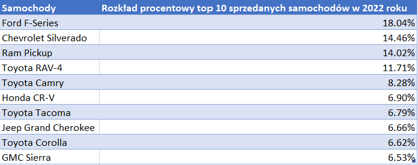

### Wykresy wykorzystane w badaniu

(Tytuły wykresów są celowo dobrane w ten sposób, aby odpowiadający myśleli, że każdy wykres to dane z innego roku)

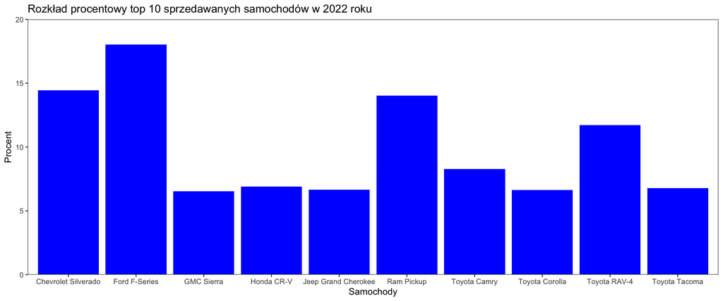

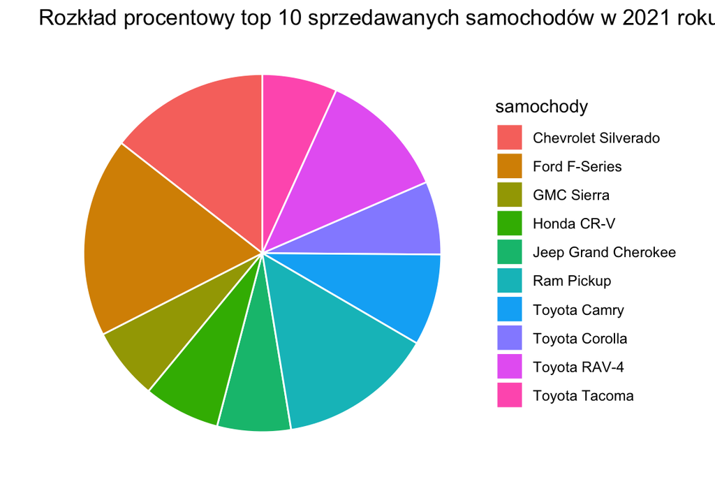

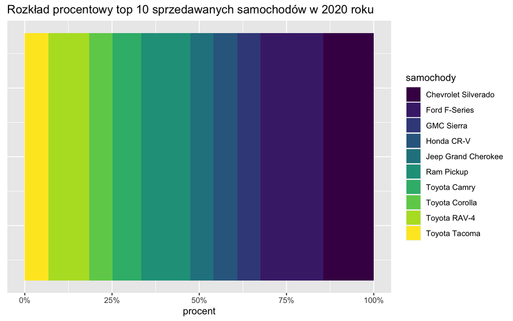

## Oceny wykresów

Pierwszym pytaniem było pytanie: Który wykres uważasz za najbardziej czytelny? Tak przedstawiają się wyniki ankiety przeprowadzonej na studentach kierunków poza IAD-em w Google Forms:

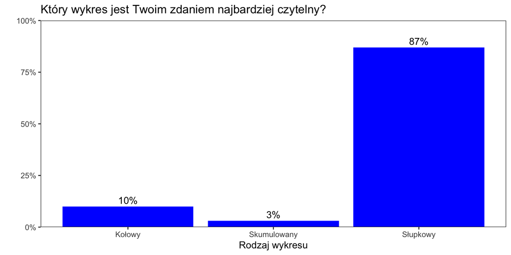

## Odpowiedzi na zadane pytania

Ankietowani byli również proszeni o odpowiedź na pytania: 1. Który samochód był drugim najczęściej wybieranym samochodem w danym roku? 2. Który samochód był czwartym najczęściej wybieranym samochodem w danym roku?

Tak przedstawiają się wyniki tej ankiety:

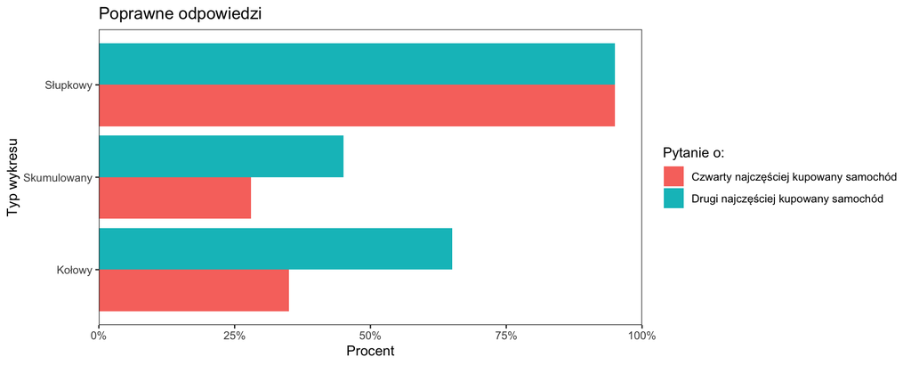

## Eksperyment 2

### Opis ankiety

W badaniu pokazałem uczestnikom ankiety 2 typy wykresów, zawierających te same dane (wykres słupkowy segmentowy, wykres słupkowy 3D). Zadałem im następujące pytania:

1. Który wykres Twoim zdaniem jest najbardziej czytelny?
2. Na podstawie wykresu, który tenisista zdobył najwięcej tytułów Wimbledon
3. Ile tytułów French Open posiada Novak Djokovic?

### Dane

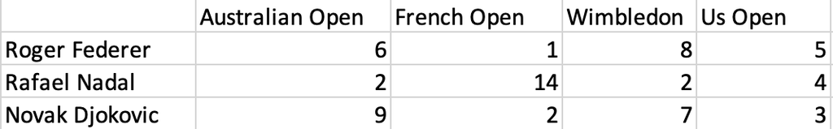

### Wykresy wykorzystane w badaniu

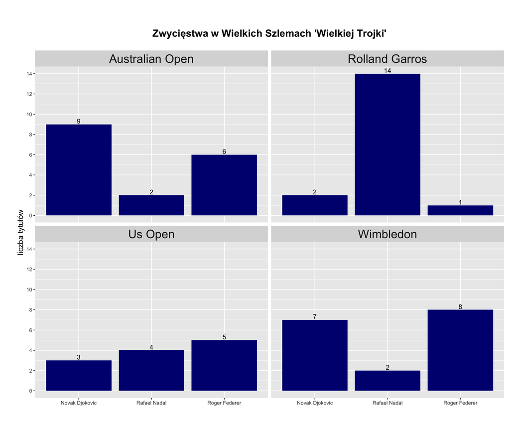

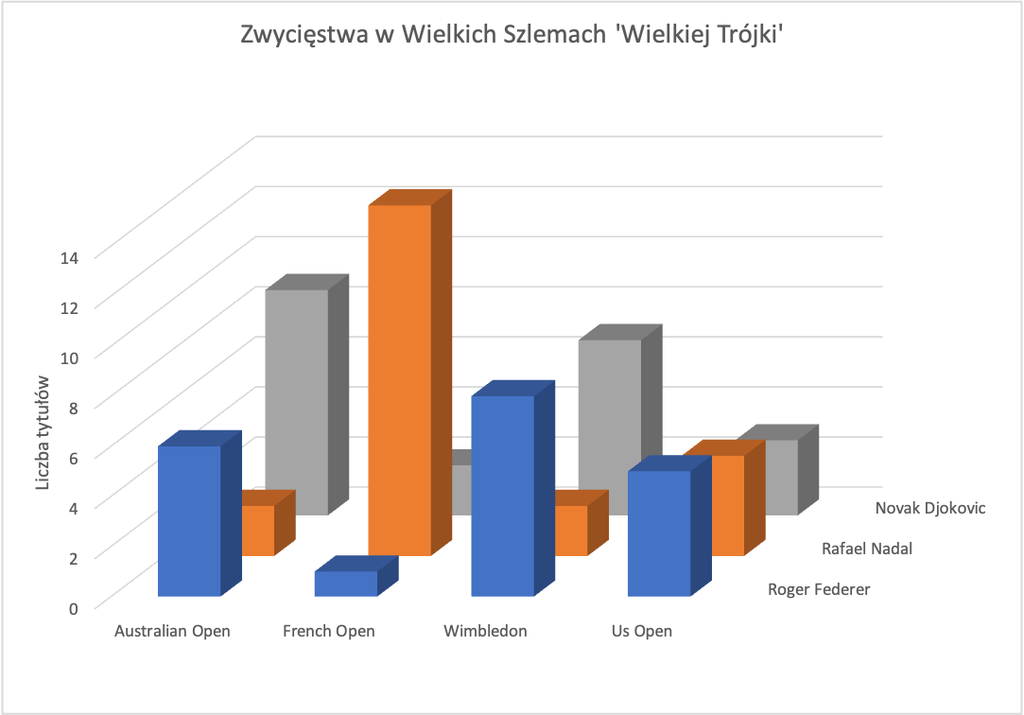

## Wyniki ankiety

93% ankietowanych oceniło wykres segmentowy jako bardziej czytelny. Jeśli chodzi o drugie pytanie to odpowiedzi aż 37% ankietowanych, którzy odczytywali dane z wykresu 3D, niepokrywały się z rzeczywistymi danymi, podczas gdy dla ankietowanych odczytujących dane z wykresu segmentowego nie było żadnej niepoprawnej odpowiedzi. Podczas ostatniego pytania 27% ankietowanych nie udało się udzielić poprawnej odpowiedzi patrząc na wykres 3D, a jedynie 1 osoba ankietowana pomyliła się patrząc na wykres segmentowy.

## Wnioski i podsumowanie

Wyniki ankiet obu eksperymentów potwierdzają, iż “dobre praktyki” w przedstawianiu danych powinny być nadal stosowane, gdyż problemy z odczytem ze “złych” wykresów wciąż występują. Wykres kołowy, skumulowany oraz 3D jest dużo bardziej mylący i ciężki w odczycie dla ludzi od wykresu słupkowego, bądź słupkowego segementowego.